# Cluster Analysis

WDI Indicators

Aida Ramezani 95105595

2018-06-17 22:54:42

> با توجه به داده بانک جهانی به سوالات زیر پاسخ دهید. برای استفاده از داده از سه فایل زیر استفاده نمایید. داده نام کشورها: WDICountry داده نام سری های زمانی: WDISeries داده کل: WDIData در صورتی که داده را در اختیار ندارید می توانید از بسته WDI استفاده نموده و داده های مورد نظر را استخراج نمایید.

۱. ده کشور فقیر دنیا را بیابید. نمودار درآمد روزانه آنها را رسم کنید. چند درصد از اعضای این کشورها زیر خط فقر هستند؟ متوسط عمر در این کشورها چقدر است؟

```r
series = read_csv("data/WDISeries.csv")
cntry = read_csv("data/cntry.csv")
investment = read_csv("data/Foreign investment inflow.csv")
WDI_data$country -> countries
countries %>% data.frame() -> countries
secondaryIncome = WDI(country = 'all', indicator = "BM.TRF.PRVT.CD")
poverty = WDI(country = 'all', indicator = "SI.POV.NAHC")
life_exceptancy = WDI(country = "all", indicator = "SP.DYN.LE00.IN")
health_expenditure = WDI(country = "all", indicator = "SH.XPD.CHEX.GD.ZS")
```

[interactive chart not shown]

```
## # A tibble: 10 x 2
##    country               povertyPercent
##    <chr>                          <dbl>
##  1 Lesotho                         57.1
##  2 Tuvalu                          26.3
##  3 Kiribati                        21.8
##  4 Vanuatu                         12.7
##  5 Sao Tome and Principe           66.2
##  6 Zimbabwe                        72.3
##  7 Burundi                         67.1
##  8 Sierra Leone                    52.9
##  9 Nicaragua                       45.4
## 10 Malawi                          50.7
```

```
## # A tibble: 9 x 2
##   country               life_exceptancy_average
##   <chr>                                   <dbl>
## 1 Burundi                                  54.0
## 2 Kiribati                                 65.2
## 3 Lesotho                                  49.1
## 4 Malawi                                   54.2
## 5 Nicaragua                                73.0
## 6 Sao Tome and Principe                    65.4
## 7 Sierra Leone                             46.4
## 8 Vanuatu                                  70.1
## 9 Zimbabwe                                 49.7
```

۲. تراژدی روآندا: بر اساس داده های امید به زندگی ابتدا نمودار سالانه نمودار جعبه ایی امید به زندگی کشورها را رسم نمایید(در یک نمودار!). سپس سری زمانی امید به زندگی روآندا را به آن اضافه کنید. چه می بینید؟ چند میلیون نفر کشته شدند؟

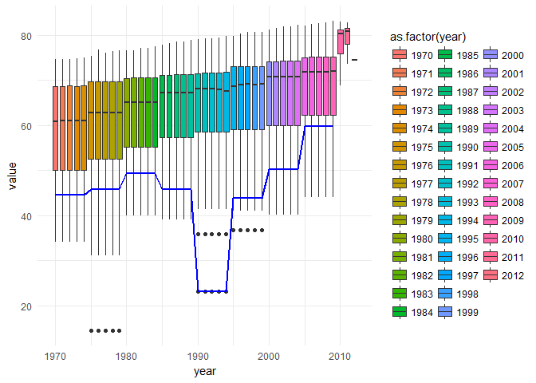

```
##    value
## 1 22.664
```

۳. نمودار امید به زندگی و هزینه های بهداشتی را رسم کنید. چه نتیجه ایی می گیرید؟

امید به زندگی با هزینه های بهداشتی رابطه مستقیم دارد. برای بهتر نشان دادن این موضوع نیز از آزمون فرض cor.test استفاده شده است.

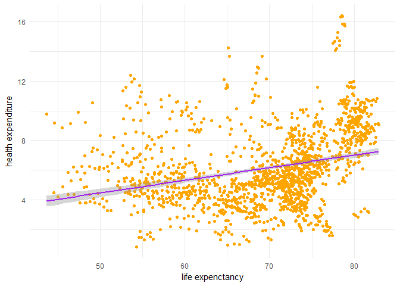

```
##
##  Pearson's product-moment correlation
##
## data:  life_health$SH.XPD.CHEX.GD.ZS and life_health$SP.DYN.LE00.IN
## t = 12.103, df = 1562, p-value < 2.2e-16
## alternative hypothesis: true correlation is not equal to 0
## 95 percent confidence interval:
##  0.2468319 0.3374847
## sample estimates:
##       cor
## 0.2928162
```

۴. آیا قدرت خرید خانواده های ایرانی در ۵۰ سال اخیر افزایش یافته است؟ برای این کار از داده های اقتصادی خانوار استفاده کنید.

از داده درامد خانواده های ایرانی استفاده کردیم. ابتدا نموداری کشیده شده است که رابطه درامد را با سال نشان میدهد. سپس با استفاده از آزمون فرض cor.test نشان دادیم که درامد با سال در ارتباط بوده و در سال های آخر درامد ایرانی ها افزایش یافته است.

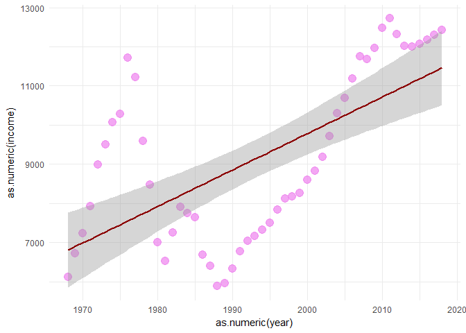

```
##
##  Pearson's product-moment correlation
##
## data:  IranIncome$year %>% as.numeric() and IranIncome$income %>% as.numeric()
## t = 5.6938, df = 49, p-value = 6.911e-07
## alternative hypothesis: true correlation is not equal to 0
## 95 percent confidence interval:
##  0.4302465 0.7722959
## sample estimates:
##       cor
## 0.6310118
```

۵. رشد اقتصادی ایران را با کشورهای دیگر در طول ۲۰ سال گذشته بر حسب بیست شاخص های اقتصادی مهم مانند تولید ناخالص ملی، تورم و … ارزیابی کنید! (برای هر شاخص از تصویرسازی استفاده کنید.)

به دلیل اینکه داده های WDI فقط شامل 5 سال اخیر هستند از داده های سایت GapMinder استفاده کردیم. البته برای قسمت Education از داده های کتابخانه WDI استفاده کردیم.

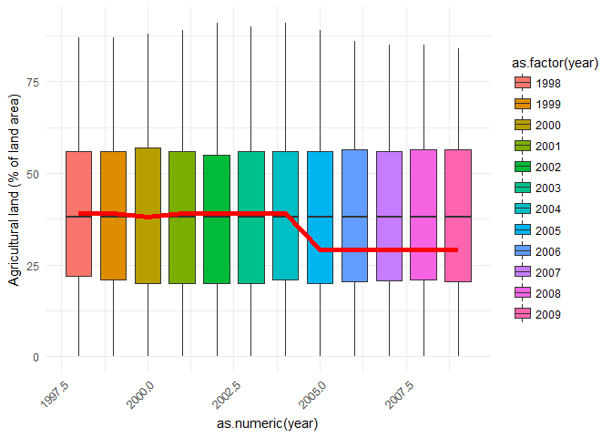

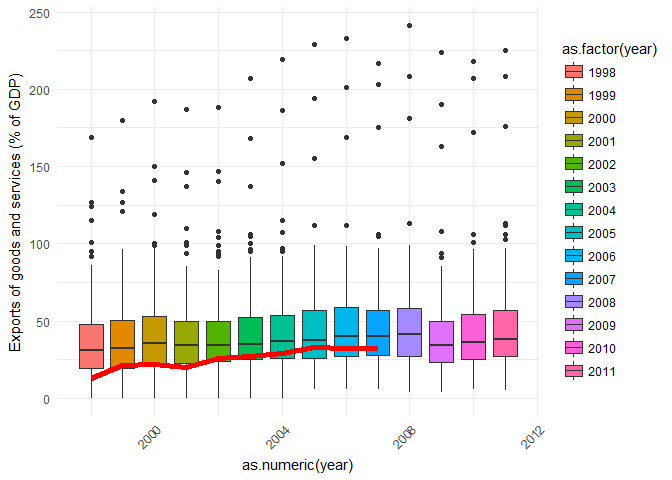

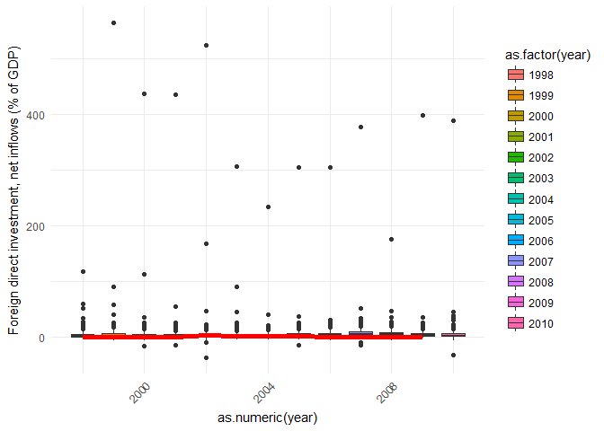

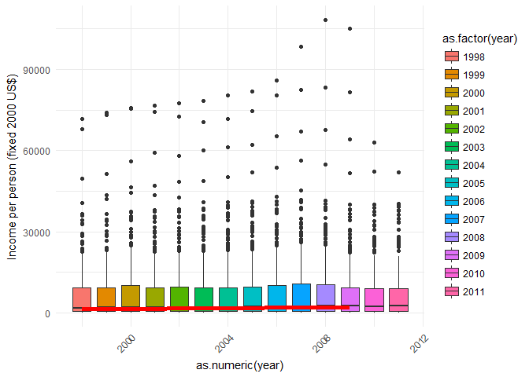

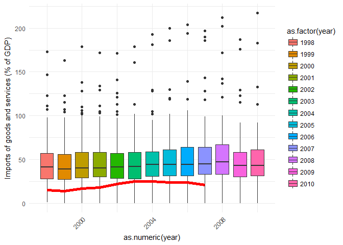

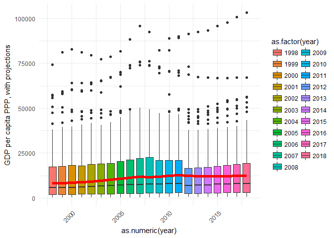

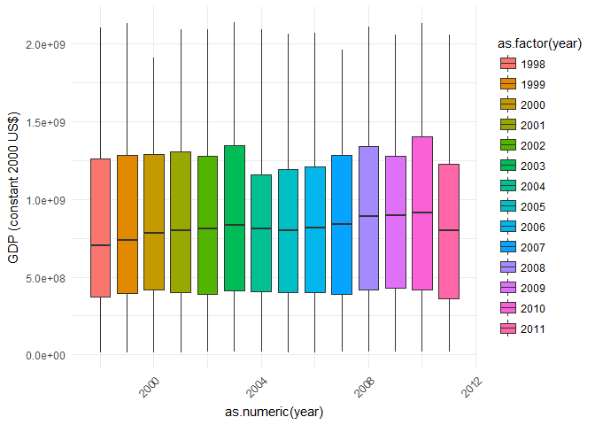

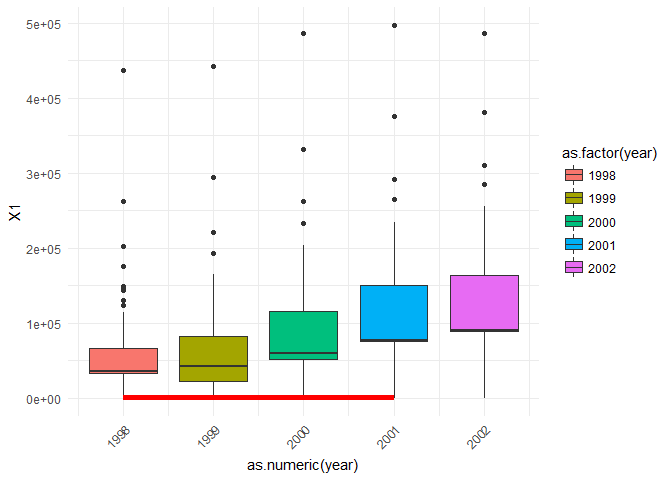

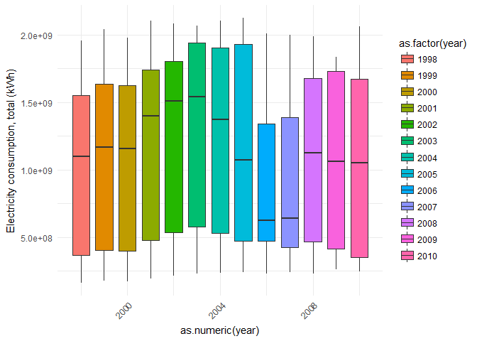

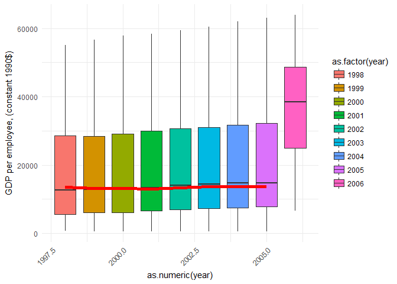

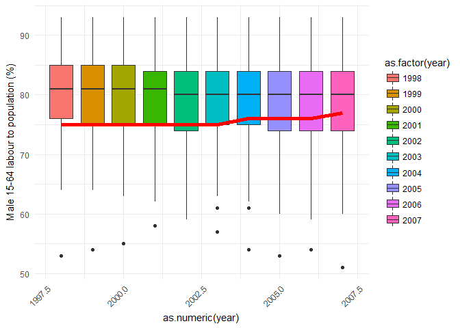

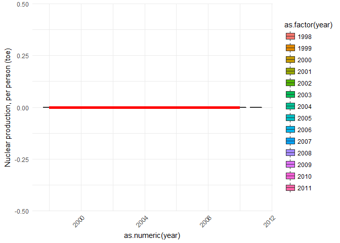

[9 more figures not shown]

***

۶. در قسمت قبل با استفاده از روش خوشه بندی k-means داده ها را به سه دسته تقسیم کنید. ایران در کدام دسته می گنجد؟ (پیش از خوشه بندی طبیعتا داده را باید پاکسازی و استاندارد سازی نمایید.)

به دلیل اینکه داده مورد نظر NA زیاد داشت از این تکنینک استفاده کردیم که خانه های NA را برابر با میانگین ستون قرار دادیم.

```r
sapply(final_df[, -1], as.numeric) -> final_df_no_country
imputeTS::na.mean(final_df_no_country) ->final_df_no_country


final_df_no_country %>% as.data.frame() -> final_df_no_country
final_df_no_country$country = final_df$country

final_df_no_country %>%
  select(-year) %>%
  group_by(country) %>%
  summarise_all(funs(mean)) -> final_df_no_country

final_df_no_country$country -> countries


final_df_no_country %>% select(-country) %>%
  mutate_if(is.numeric, scale) -> normalized_final_df


normalized_final_df %>%
  as.matrix() -> final_df_mat

row.names(final_df_mat) <- countries
#algorithm tajamoyi :

kcl = kmeans(final_df_mat,centers = 3)
kcl
```

```
## K-means clustering with 3 clusters of sizes 103, 167, 28
##
## Cluster means:
##   Agricultural land (% of land area)
## 1                          0.5778406
## 2                         -0.2977430
## 3                         -0.3498034
##   Exports of goods and services (% of GDP)
## 1                               -0.5538139
## 2                                0.2084058
## 3                                0.7942523
##   Foreign direct investment, net inflows (% of GDP)
## 1                                       -0.12529077
## 2                                       -0.01170478
## 3                                        0.53070173
##   Income per person (fixed 2000 US$)
## 1                       -0.634902579
## 2                       -0.002798506
## 3                        2.352225575
##   Imports of goods and services (% of GDP)
## 1                               -0.3316893
## 2                                0.1666370
## 3                                0.2262720
##   GDP per capita PPP, with projections GDP (constant 2000 US$)          X1
## 1                          -0.73379928              -0.1585388 -0.28443513
## 2                           0.07669667              -0.0746793 -0.07218728
## 3                           2.24189220               1.0286049  1.47686051
##   Cross sectors aid (% of total aid) Education aid (% of total aid)
## 1                         0.00000000                     0.00000000
## 2                        -0.04199458                     0.06518769
## 3                         0.25046768                    -0.38879802
##   Electricity consumption, total (kWh) Female long-term unemployment (%)
## 1                          -0.12405520                       -0.02085264
## 2                          -0.03721452                        0.16353810
## 3                           0.67830395                       -0.89868002
##   GDP per employee, (constant 1990$)
## 1                        -0.69087527
## 2                         0.09463808
## 3                         1.97698552
##   GDP per working hour, (constant 1990$)
```

[output cut: 342 more lines]

```
##                                 2                                 1
##                        Yugoslavia                            Zambia
##                                 2                                 1
##                          Zimbabwe                              <NA>
##                                 1                                 2
##
## Within cluster sum of squares by cluster:
## [1] 1251.943 2249.542 3713.765
##  (between_SS / total_SS =  19.0 %)
##
## Available components:
##
## [1] "cluster"      "centers"      "totss"        "withinss"
## [5] "tot.withinss" "betweenss"    "size"         "iter"
## [9] "ifault"
```

۷. به وسیله تحلیل مولفه اصلی بعد داده رو به دو کاهش دهید سپس خوشه های به دست آمده در قسمت قبل را بر روی آن نمایش دهید. آیا عملکرد روش خوشه بندی شما مطلوب بوده است؟

مشاهده میشود که پس از اعمال pca رتبه بندی ایران تغییر نکرده است اما بسیاری از کشور ها دچار تغییر رتبه شده اند. به عبارت دیگر بعد از pca این رتبه بندی ها دقیق تر شده اند.

```
## K-means clustering with 3 clusters of sizes 27, 120, 151
##
## Cluster means:
##          PC1        PC2
## 1 -6.5483651  0.6041973
## 2  1.7428004 -0.4855721
## 3 -0.2141072  0.2778498
##
## Clustering vector:
##                          <c5>land                          Abkhazia
##                                 3                                 3
##                       Afghanistan             Akrotiri and Dhekelia
##                                 2                                 3
##                           Albania                           Algeria
##                                 2                                 2
##                    American Samoa                           Andorra
##                                 3                                 3
##                            Angola                          Anguilla
##                                 2                                 3
##                        Antarctica               Antigua and Barbuda
##                                 3                                 3
##                         Argentina                           Armenia
##                                 2                                 2
##                             Aruba                         Australia
##                                 3                                 1
##                           Austria                        Azerbaijan
##                                 1                                 2
##                           Bahamas                           Bahrain
##                                 3                                 3
##                        Bangladesh                          Barbados
##                                 2                                 3
##                           Belarus                           Belgium
##                                 2                                 1
##                            Belize                             Benin
##                                 3                                 2
##                           Bermuda                            Bhutan
##                                 1                                 2
##                           Bolivia                           Bonaire
##                                 2                                 3
## Bonaire, Saint Eustatius and Saba            Bosnia and Herzegovina
```

[output cut: 262 more lines]

```
##                                 3                                 2
##                        Yugoslavia                            Zambia
##                                 3                                 2
##                          Zimbabwe                              <NA>
##                                 2                                 3
##
## Within cluster sum of squares by cluster:
## [1] 1114.1086  182.6132  177.7728
##  (between_SS / total_SS =  51.7 %)
##
## Available components:
##
## [1] "cluster"      "centers"      "totss"        "withinss"
## [5] "tot.withinss" "betweenss"    "size"         "iter"
## [9] "ifault"
```

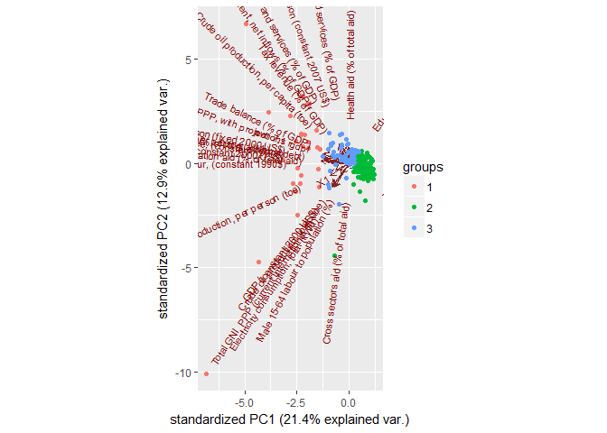

۸. با استفاده از داده روشی برای پیش بینی رشد اقتصادی ایران در سال آینده ارائه دهید.

البتدا شاخص رشد اقتصادی کشور هارا استخراج کردیم سپس با استفاده از دیگر شاخص های اقتصادی به دست آمده در قسمت قبل و با استفاده از مدل h2o.glm سعی کردیم مدلی برای رشد اقتصادی ایران بیابیم. البته چون داده های ما تعداد زیادی NA دارند، تنها داده های سال های1965تا 2009 را توانستیم استفاده کنیم. مدل ساخته شده در زیر قابل مشاهده است.

[output not shown]

```
## [1] "MSE:  5.36550561284669"
```

```
## Model Details:
## ==============
##
## H2ORegressionModel: glm
## Model Key:  GLM_model_R_1529251113806_6
## GLM Model: summary
##     family     link                              regularization
## 1 gaussian identity Elastic Net (alpha = 0.5, lambda = 0.5826 )
##   number_of_predictors_total number_of_active_predictors
## 1                         17                          10
##   number_of_iterations       training_frame
## 1                    2 Iran_economic_growth
##
## H2ORegressionMetrics: glm
## ** Reported on training data. **
##
## MSE:  4.161566
## RMSE:  2.039992
## MAE:  1.664486
## RMSLE:  NaN
## Mean Residual Deviance :  4.161566
## R^2 :  0.7108963
## Null Deviance :647.7623
## Null D.o.F. :44
## Residual Deviance :187.2704
## Residual D.o.F. :34
## AIC :215.8696
##
##
##
## H2ORegressionMetrics: glm
## ** Reported on cross-validation data. **
## ** 5-fold cross-validation on training data (Metrics computed for combined holdout predictions) **
##
## MSE:  5.365506
## RMSE:  2.316356
## MAE:  1.885769
## RMSLE:  NaN
## Mean Residual Deviance :  5.365506
## R^2 :  0.6272587
```

[output cut: 40 more lines]

```
## 3                                GDP (constant 2000 US$)     0.385046  NEG
## 4                      Crude oil production, total (toe)     0.375279  POS
## 5               Exports of goods and services (% of GDP)     0.347243  POS
## 6      Foreign direct investment, net inflows (% of GDP)     0.212642  POS
## 7                               Trade balance (% of GDP)     0.194875  POS
## 8                                 Tax revenue (% of GDP)     0.108758  POS
## 9                                          pwt 7.1 rgdpl     0.082838  POS
## 10                    Agricultural land (% of land area)     0.073321  POS
## 11                    Income per person (fixed 2000 US$)     0.000000  POS
## 12              Imports of goods and services (% of GDP)     0.000000  POS
## 13                  GDP per capita PPP, with projections     0.000000  POS
## 14                  Electricity consumption, total (kWh)     0.000000  POS
## 15                    GDP per employee, (constant 1990$)     0.000000  POS
## 16 Residential electricity consumption, per person (kWh)     0.000000  POS
## 17                    GNI per capita (constant 2000 US$)     0.000000  POS
```

۹. سوالهای ۵ تا ۷ را ابتدا برای ۲۰ شاخص سلامت سپس بر حسب ۲۰ شاخص آموزشی تکرار کنید.

سوال 5 برای شاخص های سلامت

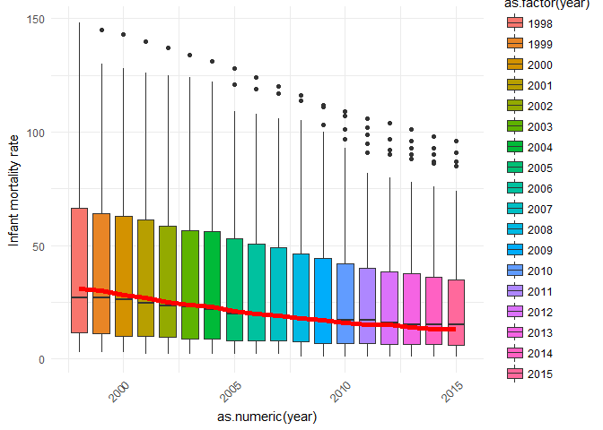

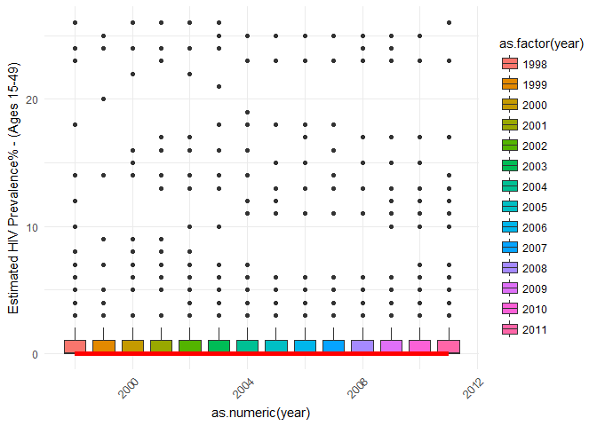

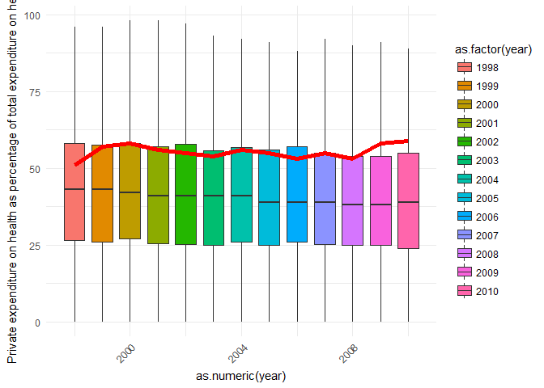

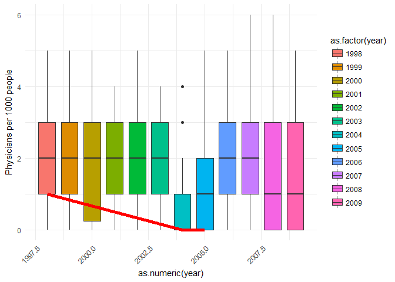

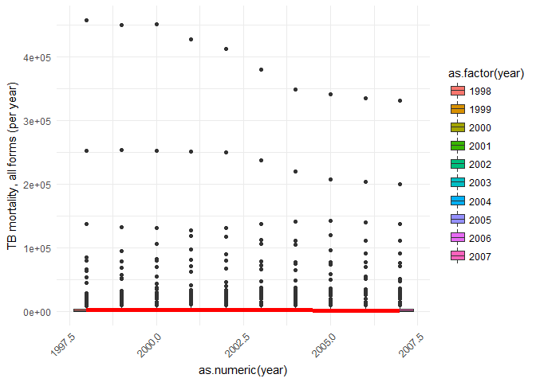

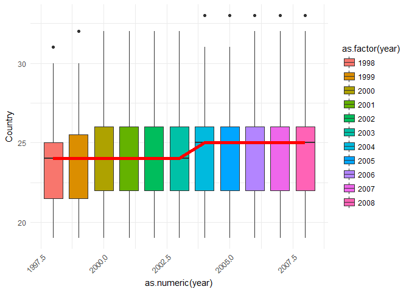

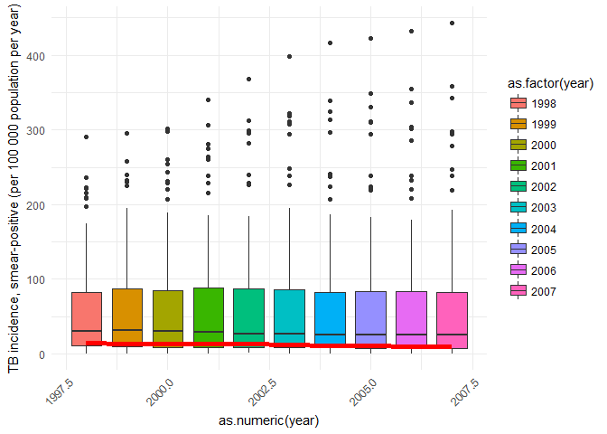

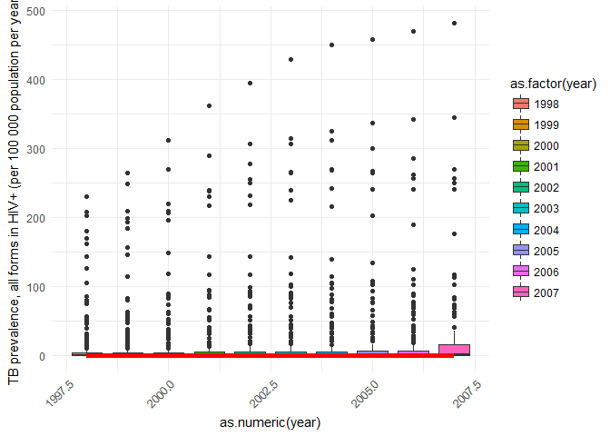

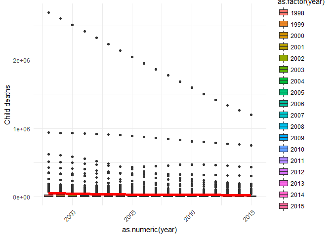

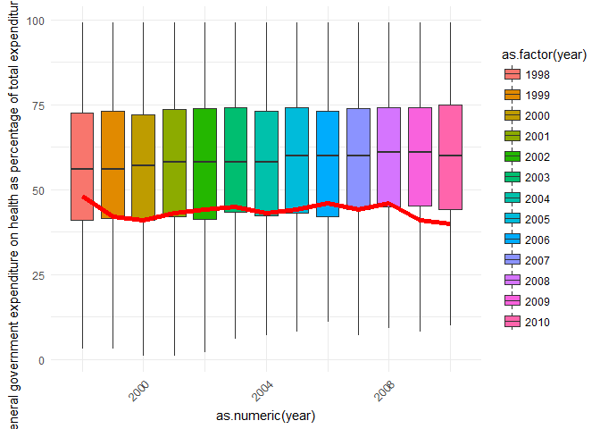

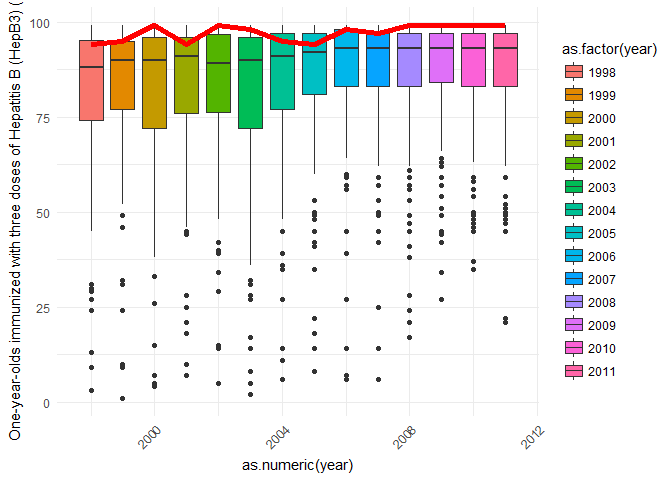

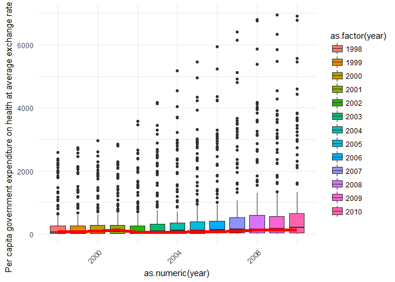

[6 more figures not shown]

سوال 6 برای شاخص های سلامت

```
## K-means clustering with 3 clusters of sizes 49, 190, 56
##
## Cluster means:
##   Infant mortality rate Estimated HIV Prevalence% - (Ages 15-49)
## 1            -1.0320710                               -0.4685359
## 2            -0.1922974                               -0.1355328
## 3             1.5554998                                0.8698125
##   Private expenditure on health as percentage of total expenditure on health
## 1                                                                -0.97084549
## 2                                                                -0.03472225
## 3                                                                 0.96729745
##   Physicians per 1000 people TB mortality, all forms (per year)    Country
## 1                  1.4823170                         -0.2555373  0.7770108
## 2                 -0.1273294                         -0.1435287  0.1883880
## 3                 -0.8650169                          0.7105673 -1.3190578
##   TB incidence, smear-positive (per 100 000 population per year)
## 1                                                     -0.6907417
## 2                                                     -0.2448709
## 3                                                      1.4352110
##   TB prevalence, all forms in HIV+ (per 100 000 population per year)
## 1                                                         -0.3467525
## 2                                                         -0.2150675
## 3                                                          1.0331019
##   Child deaths
## 1   -0.2605542
## 2   -0.1346090
## 3    0.6846940
##   General government expenditure on health as percentage of total expenditure on health
## 1                                                                            0.96701264
## 2                                                                            0.03547856
## 3                                                                           -0.96650975
##   Health aid (% of total aid)
## 1                0.0493640902
## 2               -0.0128568305
## 3                0.0004278105
##   One-year-olds immunized with three doses of Hepatitis B (HepB3) (%)
## 1                                                           0.2190596
## 2                                                           0.1587163
## 3                                                          -0.7301790
##   Per capita government expenditure on health at average exchange rate (US$)
```

[output cut: 320 more lines]

```
##                                2                                2
##                       Yugoslavia                           Zambia
##                                2                                3
##                         Zimbabwe
##                                3
##
## Within cluster sum of squares by cluster:
## [1]  958.8894 1165.0708 1826.7250
##  (between_SS / total_SS =  29.3 %)
##
## Available components:
##
## [1] "cluster"      "centers"      "totss"        "withinss"
## [5] "tot.withinss" "betweenss"    "size"         "iter"
## [9] "ifault"
```

سوال 7 برای شاخص سلامت

```
## K-means clustering with 3 clusters of sizes 69, 50, 176
##
## Cluster means:
##         PC1        PC2
## 1 -2.686667 -0.9000361
## 2  4.310824 -0.1823045
## 3 -0.171370  0.4046461
##
## Clustering vector:
##                         <c5>land                         Abkhazia
##                                3                                3
##                      Afghanistan            Akrotiri and Dhekelia
##                                2                                3
##                          Albania                          Algeria
##                                3                                3
##                   American Samoa                          Andorra
##                                3                                1
##                           Angola                         Anguilla
##                                2                                3
##                       Antarctica              Antigua and Barbuda
##                                3                                1
##                        Argentina                          Armenia
##                                3                                3
##                            Aruba                        Australia
##                                3                                1
##                          Austria                       Azerbaijan
##                                1                                3
##                          Bahamas                          Bahrain
##                                3                                1
##                       Bangladesh                         Barbados
##                                2                                3
##                          Belarus                          Belgium
##                                1                                1
##                           Belize                            Benin
##                                3                                3
##                          Bermuda                           Bhutan
##                                1                                3
##                          Bolivia                          Bonaire
##                                3                                3
##           Bosnia and Herzegovina                         Botswana
```

[output cut: 260 more lines]

```
##                                3                                3
##                       Yugoslavia                           Zambia
##                                3                                2
##                         Zimbabwe
##                                2
##
## Within cluster sum of squares by cluster:
## [1] 101.2076 737.8397 220.2257
##  (between_SS / total_SS =  58.9 %)
##
## Available components:
##
## [1] "cluster"      "centers"      "totss"        "withinss"
## [5] "tot.withinss" "betweenss"    "size"         "iter"
## [9] "ifault"
```